# Live Lecture 4 Supplemental Notebook

## Data 100, Summer 2020

Suraj Rampure and Allen Shen

```python
import pandas as pd
import numpy as np
import seaborn as sns
import matplotlib.pyplot as plt
import sklearn.linear_model as lm
```

## 1. An overview of the modeling process

1. Choose a model
2. Choose a loss function
   - `model = lm.LinearRegression()` does both of these for us!
3. Minimize average loss to find the optimal $\hat{\theta}$
   - `model.fit(X, y)`
   - `model.coef_` and `model.intercept_` give us the values of $\hat{\theta}$ after fitting

Use our model to make predictions: $\hat{\mathbb{Y}} = \mathbb{X} \hat{\theta}$

- `model.predict(X)`

## 2. RMSE on training data never increases by adding more features

```python
df = sns.load_dataset('tips')
df.head()
```

|  | total_bill | tip | sex | smoker | day | time | size |
| --- | --- | --- | --- | --- | --- | --- | --- |
| 0 | 16.99 | 1.01 | Female | No | Sun | Dinner | 2 |
| 1 | 10.34 | 1.66 | Male | No | Sun | Dinner | 3 |
| 2 | 21.01 | 3.50 | Male | No | Sun | Dinner | 3 |
| 3 | 23.68 | 3.31 | Male | No | Sun | Dinner | 2 |
| 4 | 24.59 | 3.61 | Female | No | Sun | Dinner | 4 |

```python
def rmse(y, yhat):
    return np.sqrt(np.mean((y - yhat)**2))
```

Let's start by fitting a simple linear regression model to our familiar `tips` data. Specifically, we will use `total_bill` to predict `tip`.

```python
model1 = lm.LinearRegression()
model1.fit(df[['total_bill']], df['tip'])
pred1 = model1.predict(df[['total_bill']])
```

```python
rmse(df['tip'], pred1)
```

```
1.0178504025697377
```

```python
model1.coef_
```

```
array([0.10502452])
```

```python
model1.intercept_
```

```
0.9202696135546731
```

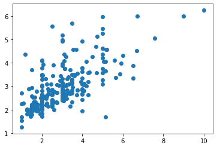

```python
plt.scatter(df['tip'], pred1);
```

Notably, our RMSE was 1.0178504025697377.

Now, let's add a completely unrelated column to our data, and include it as a feature in our model.

```python
df['useless'] = np.random.randn(len(df)) * 342
```

```python
df
```

|  | total_bill | tip | sex | smoker | day | time | size | useless |
| --- | --- | --- | --- | --- | --- | --- | --- | --- |
| 0 | 16.99 | 1.01 | Female | No | Sun | Dinner | 2 | 131.771350 |
| 1 | 10.34 | 1.66 | Male | No | Sun | Dinner | 3 | 142.896971 |
| 2 | 21.01 | 3.50 | Male | No | Sun | Dinner | 3 | 26.060033 |
| 3 | 23.68 | 3.31 | Male | No | Sun | Dinner | 2 | -84.694002 |
| 4 | 24.59 | 3.61 | Female | No | Sun | Dinner | 4 | -122.228618 |
| ... | ... | ... | ... | ... | ... | ... | ... | ... |
| 239 | 29.03 | 5.92 | Male | No | Sat | Dinner | 3 | -421.752080 |
| 240 | 27.18 | 2.00 | Female | Yes | Sat | Dinner | 2 | -156.040601 |
| 241 | 22.67 | 2.00 | Male | Yes | Sat | Dinner | 2 | -261.258523 |
| 242 | 17.82 | 1.75 | Male | No | Sat | Dinner | 2 | 53.197656 |
| 243 | 18.78 | 3.00 | Female | No | Thur | Dinner | 2 | -403.448678 |

244 rows × 8 columns

```python
model2 = lm.LinearRegression()
model2.fit(df[['total_bill', 'useless']], df['tip'])
pred2 = model2.predict(df[['total_bill', 'useless']])
```

```python
rmse(df['tip'], pred2)
```

```
1.0155449131945493
```

```python
model2.coef_
```

```
array([ 0.10487718, -0.00019831])
```

```python
model2.intercept_
```

```
0.9177561519777169
```

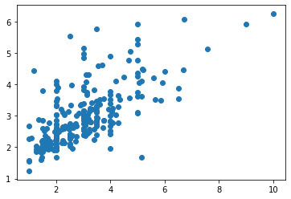

```python
plt.scatter(df['tip'], pred2);
```

Our new RMSE was marginally lower! Why?

Note that the coefficient for our `useless` feature is very close to 0.

### What about Multiple $R^2$?

For the original model:

```python
np.corrcoef(pred1, df['tip'])[0, 1]**2
```

```
0.4566165863516758
```

```python
np.var(pred1) / np.var(df['tip'])
```

```
0.4566165863516756
```

Note: `model.score` for a LinearRegression model also computes the $R^2$ value! See:

```python
model1.score(df[['total_bill']], df['tip'])
```

```
0.45661658635167657
```

You should note that the above three are all the same.

For the model with the useless feature:

```python
np.var(pred2) / np.var(df['tip'])
```

```
0.4590753875504143
```

Recall, we can interpret $R^2$ as being the proportion of variance in our true $y$ values that our fitted values capture. This is saying that our model with the useless feature included accounts for more of the variation in our true $y$ values than the first model does.

Does this make sense?

### Let's look at how such a model performs on unseen ("test") data.

We haven't yet formally taught you how to use `scikit-learn`'s inbuilt train/test split, so we will do this by hand for now.

```python
idx = np.arange(len(df))
np.random.shuffle(idx)
```

```python
idx
```

```
array([  1, 201,  71, 154,  33, 183,  38, 232,  88, 224, 144, 139, 240,
       187, 195, 226,  53,  98, 149,  22, 210,  46, 181, 173,  70, 213,
        54,  64,  48,  73, 134,  99,   2,  26, 116,  11, 118,   8,  78,
        89, 124, 158, 186, 112, 138,  96, 163,  31, 108, 105,  94, 188,
       217, 171,  37,   5, 145, 129,  86,  58,   4, 206, 161, 242,  32,
       153, 192, 177,  44,  65, 142, 231,  90,  68, 125, 172,  80,  61,
       214, 165, 109, 236, 126, 209, 141, 241, 151, 238, 228, 212, 176,
        25,  66, 104, 235, 203,   9,  23, 101,  77,  72,  30, 170, 220,
       202,  67, 119, 137, 123,  20,  18,  55, 204, 136,  42,  85,  10,
        36,  14,  35,  92, 199,  60,  15, 239,  39, 184, 155, 211, 185,
       215,  40, 100,  21, 222, 115, 243, 120, 233, 156, 102,   6,  17,
       175,  81,  95, 107, 230, 194,  87,  63, 147, 111,  82,  50, 167,
       121, 150, 207,  75, 113, 219,  27, 152,  69, 216,  79, 182,  93,
        51, 218,  59, 190,  91,  29, 114,  24,  43, 117, 168, 127, 146,
       169, 128,   3, 174,  34, 225,  41, 110, 132, 221, 189, 160,  76,
       234,  62, 200, 143,  83, 130,  28, 164,  16,  57, 227,   7,  45,
        47, 229, 178, 197,  56, 179,  49, 135, 131, 208,  19, 103, 162,
       180, 157, 198, 237, 193,  97, 159,  84, 122, 196, 148,   0, 140,
       191, 106, 133,  13,  12, 166, 223,  52,  74, 205])
```

```python
len(idx)
```

```
244
```

```python
split_point = int((3/4) * len(idx))
```

```python
split_point
```

```
183
```

```python
train, test = df.iloc[idx[:split_point]], df.iloc[idx[split_point:]]
```

```python
train
```

|  | total_bill | tip | sex | smoker | day | time | size | useless |
| --- | --- | --- | --- | --- | --- | --- | --- | --- |
| 1 | 10.34 | 1.66 | Male | No | Sun | Dinner | 3 | 142.896971 |
| 201 | 12.74 | 2.01 | Female | Yes | Thur | Lunch | 2 | -514.661072 |
| 71 | 17.07 | 3.00 | Female | No | Sat | Dinner | 3 | -225.277185 |
| 154 | 19.77 | 2.00 | Male | No | Sun | Dinner | 4 | -257.022761 |
| 33 | 20.69 | 2.45 | Female | No | Sat | Dinner | 4 | -280.069292 |
| ... | ... | ... | ... | ... | ... | ... | ... | ... |
| 117 | 10.65 | 1.50 | Female | No | Thur | Lunch | 2 | -259.823678 |
| 168 | 10.59 | 1.61 | Female | Yes | Sat | Dinner | 2 | 169.550729 |
| 127 | 14.52 | 2.00 | Female | No | Thur | Lunch | 2 | -461.221484 |
| 146 | 18.64 | 1.36 | Female | No | Thur | Lunch | 3 | -29.758910 |
| 169 | 10.63 | 2.00 | Female | Yes | Sat | Dinner | 2 | 570.352014 |

183 rows × 8 columns

```python
test
```

|  | total_bill | tip | sex | smoker | day | time | size | useless |
| --- | --- | --- | --- | --- | --- | --- | --- | --- |
| 128 | 11.38 | 2.00 | Female | No | Thur | Lunch | 2 | 46.440591 |
| 3 | 23.68 | 3.31 | Male | No | Sun | Dinner | 2 | -84.694002 |
| 174 | 16.82 | 4.00 | Male | Yes | Sun | Dinner | 2 | -1.382111 |
| 34 | 17.78 | 3.27 | Male | No | Sat | Dinner | 2 | -99.177752 |
| 225 | 16.27 | 2.50 | Female | Yes | Fri | Lunch | 2 | 26.222213 |
| ... | ... | ... | ... | ... | ... | ... | ... | ... |
| 166 | 20.76 | 2.24 | Male | No | Sun | Dinner | 2 | -72.179415 |
| 223 | 15.98 | 3.00 | Female | No | Fri | Lunch | 3 | 143.733794 |
| 52 | 34.81 | 5.20 | Female | No | Sun | Dinner | 4 | 470.422379 |
| 74 | 14.73 | 2.20 | Female | No | Sat | Dinner | 2 | -488.249524 |
| 205 | 16.47 | 3.23 | Female | Yes | Thur | Lunch | 3 | 363.289350 |

61 rows × 8 columns

```python
new_model1 = lm.LinearRegression()
new_model1.fit(train[['total_bill']], train['tip'])
new_pred1_train = new_model1.predict(train[['total_bill']])
new_pred1_test = new_model1.predict(test[['total_bill']])
```

```python
new_model1_train_rmse = rmse(train['tip'], new_pred1_train)
new_model1_test_rmse = rmse(test['tip'], new_pred1_test)

new_model1_train_rmse, new_model1_test_rmse
```

```
(1.043322299509456, 0.9434971905441378)
```

Now, for our model with the useless feature:

```python
new_model2 = lm.LinearRegression()
new_model2.fit(train[['total_bill', 'useless']], train['tip'])
new_pred2_train = new_model2.predict(train[['total_bill', 'useless']])
new_pred2_test = new_model2.predict(test[['total_bill', 'useless']])
```

```python
new_model2_train_rmse = rmse(train['tip'], new_pred2_train)
new_model2_test_rmse = rmse(test['tip'], new_pred2_test)

new_model2_train_rmse, new_model2_test_rmse
```

```
(1.0368979705593446, 0.959464772352727)
```

```python
new_model1.coef_
```

```
array([0.11048425])
```

```python
new_model2.coef_
```

```
array([ 0.11026443, -0.00032182])
```

Note, here training RMSE went down, but test RMSE went up. This is generally what happens when you include features that aren't truly relevant to the underlying relationship in your data. We call this **overfitting**.

## 3. One hot encoding

```python
import pandas as pd
import numpy as np
import seaborn as sns
import matplotlib.pyplot as plt
import sklearn.linear_model as lm

from sklearn.feature_extraction import DictVectorizer
```

```python
df = sns.load_dataset('tips')
df.head()
```

|  | total_bill | tip | sex | smoker | day | time | size |
| --- | --- | --- | --- | --- | --- | --- | --- |
| 0 | 16.99 | 1.01 | Female | No | Sun | Dinner | 2 |
| 1 | 10.34 | 1.66 | Male | No | Sun | Dinner | 3 |
| 2 | 21.01 | 3.50 | Male | No | Sun | Dinner | 3 |
| 3 | 23.68 | 3.31 | Male | No | Sun | Dinner | 2 |
| 4 | 24.59 | 3.61 | Female | No | Sun | Dinner | 4 |

### Why do we need one hot encoding?

```python
model1 = lm.LinearRegression()
model1.fit(df.drop(columns='tip'), df['tip'])
```

```
---------------------------------------------------------------------------
ValueError                                Traceback (most recent call last)
<ipython-input-36-7f6b6959884c> in <module>
      1 model1 = lm.LinearRegression()
----> 2 model1.fit(df.drop(columns='tip'), df['tip'])

/opt/anaconda3/lib/python3.7/site-packages/sklearn/linear_model/base.py in fit(self, X, y, sample_weight)
    461         n_jobs_ = self.n_jobs
    462         X, y = check_X_y(X, y, accept_sparse=['csr', 'csc', 'coo'],
--> 463                          y_numeric=True, multi_output=True)
    464
    465         if sample_weight is not None and np.atleast_1d(sample_weight).ndim > 1:

/opt/anaconda3/lib/python3.7/site-packages/sklearn/utils/validation.py in check_X_y(X, y, accept_sparse, accept_large_sparse, dtype, order, copy, force_all_finite, ensure_2d, allow_nd, multi_output, ensure_min_samples, ensure_min_features, y_numeric, warn_on_dtype, estimator)
    717                     ensure_min_features=ensure_min_features,
    718                     warn_on_dtype=warn_on_dtype,
--> 719                     estimator=estimator)
    720     if multi_output:
    721         y = check_array(y, 'csr', force_all_finite=True, ensure_2d=False,

/opt/anaconda3/lib/python3.7/site-packages/sklearn/utils/validation.py in check_array(array, accept_sparse, accept_large_sparse, dtype, order, copy, force_all_finite, ensure_2d, allow_nd, ensure_min_samples, ensure_min_features, warn_on_dtype, estimator)
    534         # make sure we actually converted to numeric:
    535         if dtype_numeric and array.dtype.kind == "O":
--> 536             array = array.astype(np.float64)
    537         if not allow_nd and array.ndim >= 3:
    538             raise ValueError("Found array with dim %d. %s expected <= 2."

ValueError: could not convert string to float: 'Female'
```

### How to perform a one hot encoding in scikit-learn

```python
df = df.drop(columns='tip')
cat_cols = ['sex', 'smoker', 'day', 'time']
```

```python
vec_enc = DictVectorizer()
vec_enc.fit(df[cat_cols].to_dict(orient='records'))
cat_data = vec_enc.transform(df[cat_cols].to_dict(orient='records')).toarray()
cat_data
```

```
array([[0., 0., 1., ..., 0., 1., 0.],
       [0., 0., 1., ..., 0., 1., 0.],
       [0., 0., 1., ..., 0., 1., 0.],
       ...,
       [0., 1., 0., ..., 1., 1., 0.],
       [0., 1., 0., ..., 0., 1., 0.],
       [0., 0., 0., ..., 0., 1., 0.]])
```

```python
cat_data_names = vec_enc.get_feature_names()
cat_data_names
```

```
['day=Fri',
 'day=Sat',
 'day=Sun',
 'day=Thur',
 'sex=Female',
 'sex=Male',
 'smoker=No',
 'smoker=Yes',
 'time=Dinner',
 'time=Lunch']
```

```python
cat_data = pd.DataFrame(cat_data, columns=cat_data_names)
df_ohe = pd.concat([df, cat_data], axis=1).drop(columns=cat_cols) # Drop original categorical columns
df_ohe.head()
```

|  | total_bill | size | day=Fri | day=Sat | day=Sun | day=Thur | sex=Female | sex=Male | smoker=No | smoker=Yes | time=Dinner | time=Lunch |
| --- | --- | --- | --- | --- | --- | --- | --- | --- | --- | --- | --- | --- |
| 0 | 16.99 | 2 | 0.0 | 0.0 | 1.0 | 0.0 | 1.0 | 0.0 | 1.0 | 0.0 | 1.0 | 0.0 |
| 1 | 10.34 | 3 | 0.0 | 0.0 | 1.0 | 0.0 | 0.0 | 1.0 | 1.0 | 0.0 | 1.0 | 0.0 |
| 2 | 21.01 | 3 | 0.0 | 0.0 | 1.0 | 0.0 | 0.0 | 1.0 | 1.0 | 0.0 | 1.0 | 0.0 |
| 3 | 23.68 | 2 | 0.0 | 0.0 | 1.0 | 0.0 | 0.0 | 1.0 | 1.0 | 0.0 | 1.0 | 0.0 |
| 4 | 24.59 | 4 | 0.0 | 0.0 | 1.0 | 0.0 | 1.0 | 0.0 | 1.0 | 0.0 | 1.0 | 0.0 |

```python
df_ohe.shape
```

```
(244, 12)
```

```python
X = pd.concat([df_ohe, pd.Series(np.ones(df_ohe.shape[0]), name='intercept')], axis=1)
X.head()
```

|  | total_bill | size | day=Fri | day=Sat | day=Sun | day=Thur | sex=Female | sex=Male | smoker=No | smoker=Yes | time=Dinner | time=Lunch | intercept |
| --- | --- | --- | --- | --- | --- | --- | --- | --- | --- | --- | --- | --- | --- |
| 0 | 16.99 | 2 | 0.0 | 0.0 | 1.0 | 0.0 | 1.0 | 0.0 | 1.0 | 0.0 | 1.0 | 0.0 | 1.0 |
| 1 | 10.34 | 3 | 0.0 | 0.0 | 1.0 | 0.0 | 0.0 | 1.0 | 1.0 | 0.0 | 1.0 | 0.0 | 1.0 |
| 2 | 21.01 | 3 | 0.0 | 0.0 | 1.0 | 0.0 | 0.0 | 1.0 | 1.0 | 0.0 | 1.0 | 0.0 | 1.0 |
| 3 | 23.68 | 2 | 0.0 | 0.0 | 1.0 | 0.0 | 0.0 | 1.0 | 1.0 | 0.0 | 1.0 | 0.0 | 1.0 |
| 4 | 24.59 | 4 | 0.0 | 0.0 | 1.0 | 0.0 | 1.0 | 0.0 | 1.0 | 0.0 | 1.0 | 0.0 | 1.0 |

```python
X.shape
```

```
(244, 13)
```

#### What does this output?

```python
np.linalg.matrix_rank(X)
```

```
9
```

#### What's the issue with the design matrix above?

```python
X = X.drop(columns=['day=Sat', 'sex=Female', 'smoker=No', 'time=Dinner'])
X.head()
```

|  | total_bill | size | day=Fri | day=Sun | day=Thur | sex=Male | smoker=Yes | time=Lunch | intercept |
| --- | --- | --- | --- | --- | --- | --- | --- | --- | --- |
| 0 | 16.99 | 2 | 0.0 | 1.0 | 0.0 | 0.0 | 0.0 | 0.0 | 1.0 |
| 1 | 10.34 | 3 | 0.0 | 1.0 | 0.0 | 1.0 | 0.0 | 0.0 | 1.0 |
| 2 | 21.01 | 3 | 0.0 | 1.0 | 0.0 | 1.0 | 0.0 | 0.0 | 1.0 |
| 3 | 23.68 | 2 | 0.0 | 1.0 | 0.0 | 1.0 | 0.0 | 0.0 | 1.0 |
| 4 | 24.59 | 4 | 0.0 | 1.0 | 0.0 | 0.0 | 0.0 | 0.0 | 1.0 |

```python
X.shape
```

```
(244, 9)
```

#### What does this output?

```python
np.linalg.matrix_rank(X)
```

```
9
```

### One hot encoding with Pandas

```python
df_ohe2 = pd.get_dummies(df)
df_ohe2.head()
```

|  | total_bill | size | sex_Male | sex_Female | smoker_Yes | smoker_No | day_Thur | day_Fri | day_Sat | day_Sun | time_Lunch | time_Dinner |
| --- | --- | --- | --- | --- | --- | --- | --- | --- | --- | --- | --- | --- |
| 0 | 16.99 | 2 | 0 | 1 | 0 | 1 | 0 | 0 | 0 | 1 | 0 | 1 |
| 1 | 10.34 | 3 | 1 | 0 | 0 | 1 | 0 | 0 | 0 | 1 | 0 | 1 |
| 2 | 21.01 | 3 | 1 | 0 | 0 | 1 | 0 | 0 | 0 | 1 | 0 | 1 |
| 3 | 23.68 | 2 | 1 | 0 | 0 | 1 | 0 | 0 | 0 | 1 | 0 | 1 |
| 4 | 24.59 | 4 | 0 | 1 | 0 | 1 | 0 | 0 | 0 | 1 | 0 | 1 |

```python
X_2 = pd.concat([df_ohe2, pd.Series(np.ones(df_ohe2.shape[0]), name='intercept')], axis=1)
X_2.head()
```

|  | total_bill | size | sex_Male | sex_Female | smoker_Yes | smoker_No | day_Thur | day_Fri | day_Sat | day_Sun | time_Lunch | time_Dinner | intercept |
| --- | --- | --- | --- | --- | --- | --- | --- | --- | --- | --- | --- | --- | --- |
| 0 | 16.99 | 2 | 0 | 1 | 0 | 1 | 0 | 0 | 0 | 1 | 0 | 1 | 1.0 |
| 1 | 10.34 | 3 | 1 | 0 | 0 | 1 | 0 | 0 | 0 | 1 | 0 | 1 | 1.0 |
| 2 | 21.01 | 3 | 1 | 0 | 0 | 1 | 0 | 0 | 0 | 1 | 0 | 1 | 1.0 |
| 3 | 23.68 | 2 | 1 | 0 | 0 | 1 | 0 | 0 | 0 | 1 | 0 | 1 | 1.0 |
| 4 | 24.59 | 4 | 0 | 1 | 0 | 1 | 0 | 0 | 0 | 1 | 0 | 1 | 1.0 |

```python
X_2.shape
```

```
(244, 13)
```

```python
np.linalg.matrix_rank(X_2)
```

```
9
```

```python
df_ohe2 = pd.get_dummies(df, drop_first=True)
df_ohe2.head()
```

|  | total_bill | size | sex_Female | smoker_No | day_Fri | day_Sat | day_Sun | time_Dinner |
| --- | --- | --- | --- | --- | --- | --- | --- | --- |
| 0 | 16.99 | 2 | 1 | 1 | 0 | 0 | 1 | 1 |
| 1 | 10.34 | 3 | 0 | 1 | 0 | 0 | 1 | 1 |
| 2 | 21.01 | 3 | 0 | 1 | 0 | 0 | 1 | 1 |
| 3 | 23.68 | 2 | 0 | 1 | 0 | 0 | 1 | 1 |
| 4 | 24.59 | 4 | 1 | 1 | 0 | 0 | 1 | 1 |

```python
X_2 = pd.concat([df_ohe2, pd.Series(np.ones(df_ohe2.shape[0]), name='intercept')], axis=1)
X_2.head()
```

|  | total_bill | size | sex_Female | smoker_No | day_Fri | day_Sat | day_Sun | time_Dinner | intercept |
| --- | --- | --- | --- | --- | --- | --- | --- | --- | --- |
| 0 | 16.99 | 2 | 1 | 1 | 0 | 0 | 1 | 1 | 1.0 |
| 1 | 10.34 | 3 | 0 | 1 | 0 | 0 | 1 | 1 | 1.0 |
| 2 | 21.01 | 3 | 0 | 1 | 0 | 0 | 1 | 1 | 1.0 |
| 3 | 23.68 | 2 | 0 | 1 | 0 | 0 | 1 | 1 | 1.0 |
| 4 | 24.59 | 4 | 1 | 1 | 0 | 0 | 1 | 1 | 1.0 |

```python
X_2.shape
```

```
(244, 9)
```

```python
np.linalg.matrix_rank(X_2)
```

```
9
```

### More examples of one hot encoding

```python
X_3 = pd.get_dummies(df[['total_bill', 'sex']])
X_3.head()
```

|  | total_bill | sex_Male | sex_Female |
| --- | --- | --- | --- |
| 0 | 16.99 | 0 | 1 |
| 1 | 10.34 | 1 | 0 |
| 2 | 21.01 | 1 | 0 |
| 3 | 23.68 | 1 | 0 |
| 4 | 24.59 | 0 | 1 |

#### What would this output?

```python
np.linalg.matrix_rank(X_3)
```

```
3
```

```python
X_4 = pd.concat([X_3, pd.Series(np.ones(X_3.shape[0]), name='intercept')], axis=1)
X_4.head()
```

|  | total_bill | sex_Male | sex_Female | intercept |
| --- | --- | --- | --- | --- |
| 0 | 16.99 | 0 | 1 | 1.0 |
| 1 | 10.34 | 1 | 0 | 1.0 |
| 2 | 21.01 | 1 | 0 | 1.0 |
| 3 | 23.68 | 1 | 0 | 1.0 |
| 4 | 24.59 | 0 | 1 | 1.0 |

#### What would this output?

```python
np.linalg.matrix_rank(X_4)
```

```
3
```

```python
(X_4['intercept'] - X_4['sex_Male']).iloc[:5]
```

```
0    1.0
1    0.0
2    0.0
3    0.0
4    1.0
dtype: float64
```

```python
X_5 = pd.get_dummies(df[['total_bill', 'sex', 'smoker']])
X_5.tail(5)
```

|  | total_bill | sex_Male | sex_Female | smoker_Yes | smoker_No |
| --- | --- | --- | --- | --- | --- |
| 239 | 29.03 | 1 | 0 | 0 | 1 |
| 240 | 27.18 | 0 | 1 | 1 | 0 |
| 241 | 22.67 | 1 | 0 | 1 | 0 |
| 242 | 17.82 | 1 | 0 | 0 | 1 |
| 243 | 18.78 | 0 | 1 | 0 | 1 |

#### What would this output?

```python
np.linalg.matrix_rank(X_5)
```

```
4
```

```python
(X_5['sex_Male'] + X_5['sex_Female'] - X_5['smoker_Yes']).iloc[-5:]
```

```
239    1
240    0
241    0
242    1
243    1
dtype: uint8
```

```python
X_6 = pd.concat([X_5, pd.Series(np.ones(X_5.shape[0]), name='intercept')], axis=1)
X_6.tail()
```

|  | total_bill | sex_Male | sex_Female | smoker_Yes | smoker_No | intercept |
| --- | --- | --- | --- | --- | --- | --- |
| 239 | 29.03 | 1 | 0 | 0 | 1 | 1.0 |
| 240 | 27.18 | 0 | 1 | 1 | 0 | 1.0 |
| 241 | 22.67 | 1 | 0 | 1 | 0 | 1.0 |
| 242 | 17.82 | 1 | 0 | 0 | 1 | 1.0 |
| 243 | 18.78 | 0 | 1 | 0 | 1 | 1.0 |

#### What would this output?

```python
np.linalg.matrix_rank(X_6)
```

```
4
```

## 4. Duplicate features

```python
df = sns.load_dataset('tips')
```

```python
X_7 = df[['total_bill', 'size', 'size']]
X_7 = pd.concat([X_7, pd.Series(np.ones(X_7.shape[0]), name='intercept')], axis=1)
X_7.head()
```

|  | total_bill | size | size | intercept |
| --- | --- | --- | --- | --- |
| 0 | 16.99 | 2 | 2 | 1.0 |
| 1 | 10.34 | 3 | 3 | 1.0 |
| 2 | 21.01 | 3 | 3 | 1.0 |
| 3 | 23.68 | 2 | 2 | 1.0 |
| 4 | 24.59 | 4 | 4 | 1.0 |

#### What would this output?

```python
np.linalg.matrix_rank(X_7)
```

```
3
```

#### What's the issue with this again?

```python
model2 = lm.LinearRegression(fit_intercept=False)
model2.fit(X_7, df['tip'])
```

```
LinearRegression(copy_X=True, fit_intercept=False, n_jobs=None, normalize=False)
```

```python
model2_coef = model2.coef_
model2_coef
```

```
array([0.09271334, 0.0962989 , 0.0962989 , 0.66894474])
```

```python
model2.intercept_
```

```
0.0
```

```python
model2.predict(X_7)[:5]
```

```
array([2.62933992, 2.20539403, 3.19464533, 3.24959215, 3.71915687])
```

```python
X_7.iloc[:5] @ model2_coef
```

```
0    2.629340
1    2.205394
2    3.194645
3    3.249592
4    3.719157
dtype: float64
```

### How can I change the model coefficients so that the predictions are the same?

Our model is:

$$\theta_0 + \theta_1 \cdot size + \theta_2 \cdot size + \theta_3 \cdot total\_bill$$

```python
model2_coef_modified = model2_coef.copy()
model2_coef_modified[1] = model2_coef[1] - 1000000000
model2_coef_modified[2] = model2_coef[2] + 1000000000
```

```python
model2_coef
```

```
array([0.09271334, 0.0962989 , 0.0962989 , 0.66894474])
```

```python
model2_coef_modified
```

```
array([ 9.27133368e-02, -1.00000000e+09,  1.00000000e+09,  6.68944741e-01])
```

```python
X_7.iloc[:5] @ model2_coef_modified
```

```
0    2.629340
1    2.205394
2    3.194646
3    3.249592
4    3.719157
dtype: float64
```

which is the same as before!

### Using 2 times size as a feature

```python
X_8 = df[['total_bill', 'size']]
X_8.loc[:, '2 * size'] = 2 * X_8['size']
X_8 = pd.concat([X_8, pd.Series(np.ones(X_8.shape[0]), name='intercept')], axis=1)
X_8.head()
```

|  | total_bill | size | 2 * size | intercept |
| --- | --- | --- | --- | --- |
| 0 | 16.99 | 2 | 4 | 1.0 |
| 1 | 10.34 | 3 | 6 | 1.0 |
| 2 | 21.01 | 3 | 6 | 1.0 |
| 3 | 23.68 | 2 | 4 | 1.0 |
| 4 | 24.59 | 4 | 8 | 1.0 |

#### What would this output?

```python
np.linalg.matrix_rank(X_8)
```

```
3
```

```python
model3 = lm.LinearRegression(fit_intercept=False)
model3.fit(X_8, df['tip'])
```

```
LinearRegression(copy_X=True, fit_intercept=False, n_jobs=None, normalize=False)
```

```python
model3_coef = model3.coef_
model3_coef
```

```
array([0.09271334, 0.03851956, 0.07703912, 0.66894474])
```

```python
model3.predict(X_8)[:5]
```

```
array([2.62933992, 2.20539403, 3.19464533, 3.24959215, 3.71915687])
```

```python
X_8.iloc[:5] @ model3_coef
```

```
0    2.629340
1    2.205394
2    3.194645
3    3.249592
4    3.719157
dtype: float64
```

### How can I change the coefficients so that the predictions are the same?

Can I do the same thing as before?

```python
model3_coef_modified = model3_coef.copy()
model3_coef_modified[1] = model3_coef[1] - 100
model3_coef_modified[2] = model3_coef[2] + 100
```

```python
X_8.iloc[:5] @ model3_coef_modified
```

```
0    202.629340
1    302.205394
2    303.194645
3    203.249592
4    403.719157
dtype: float64
```

```python
model3_coef_modified = model3_coef.copy()
model3_coef_modified[1] = model3_coef[1] - 100
model3_coef_modified[2] = model3_coef[2] + 50
```

```python
X_8.iloc[:5] @ model3_coef_modified
```

```
0    2.629340
1    2.205394
2    3.194645
3    3.249592
4    3.719157
dtype: float64
```

### Thought exercise: What happens if I try to add 2 * size + 3 as a feature?

```python
X_9 = df[['total_bill', 'size']]
X_9.loc[:, '2 * size + 3'] = 2 * X_9['size'] + 3
X_9 = pd.concat([X_9, pd.Series(np.ones(X_8.shape[0]), name='intercept')], axis=1)
X_9.head()
```

|  | total_bill | size | 2 * size + 3 | intercept |
| --- | --- | --- | --- | --- |
| 0 | 16.99 | 2 | 7 | 1.0 |
| 1 | 10.34 | 3 | 9 | 1.0 |
| 2 | 21.01 | 3 | 9 | 1.0 |
| 3 | 23.68 | 2 | 7 | 1.0 |
| 4 | 24.59 | 4 | 11 | 1.0 |

#### What would this output?

```python
np.linalg.matrix_rank(X_9)
```

```
3
```

### Adding size squared as a feature

```python
X_10 = df[['total_bill', 'size']]
X_10.loc[:, 'size ** 2'] = X_10['size'] ** 2
X_10 = pd.concat([X_10, pd.Series(np.ones(X_10.shape[0]), name='intercept')], axis=1)
X_10.head()
```

|  | total_bill | size | size ** 2 | intercept |
| --- | --- | --- | --- | --- |
| 0 | 16.99 | 2 | 4 | 1.0 |
| 1 | 10.34 | 3 | 9 | 1.0 |
| 2 | 21.01 | 3 | 9 | 1.0 |
| 3 | 23.68 | 2 | 4 | 1.0 |
| 4 | 24.59 | 4 | 16 | 1.0 |

#### What would this output?

```python
np.linalg.matrix_rank(X_10)
```

```
4
```

## 5. What makes a model linear?

Is the following model linear? (Suppose $x$ represents a single observation of our raw data matrix.)

$$f_\theta(x) = \theta_0 + \theta_1 x_1 + \theta_2 x_2 + \theta_3 \sin(x_1) + \theta_4 \cos(x_1x_2) e^{x_1}$$

**Yes**, because it is linear in terms of the parameters. We could formulate this model as $$f_\theta(x) = x^T \theta$$ where $x = \begin{bmatrix} 1 \\ x_1 \\ x_2 \\ \sin(x_1) \\ \cos(x_1x_2) e^{x_1} \end{bmatrix}$ and $\theta = \begin{bmatrix} \theta_0 \\ \theta_1 \\ \theta_2 \\ \theta_3 \\ \theta_4 \end{bmatrix}$.

What about this model?

$$f_\theta(x) = \theta_0 + \theta_1 x + \theta_2 \sin(\theta_3 x)$$

**No**, because $\theta_3$ is within a $\sin$ function. We cannot write this model in the form $x^T \theta$, so it is not a linear model. **It is still a model, though**, and we can find its optimal parameters, but just not using least squares.